# SPY ETF ML Trading Strategy Analysis

Algorithmic Trading System

2025-07-16

# Data Load

The numeric suffix for each data set represents 1. ATR multiplier 2. Trade timeout duration (minutes). View data_mining.ipynb for how this is populated.

```r
data10_180 = read.csv("../csvs/train10_180.csv")
```

# Data exploration for 10_180

```r
summary(data10_180)
```

```
##       X2                 Open           Close            High
##  Length:11315       Min.   :416.3   Min.   :416.3   Min.   :416.4
##  Class :character   1st Qu.:429.5   1st Qu.:429.5   1st Qu.:429.6
##  Mode  :character   Median :436.0   Median :436.0   Median :436.1
##                     Mean   :434.8   Mean   :434.8   Mean   :434.9
##                     3rd Qu.:440.6   3rd Qu.:440.6   3rd Qu.:440.7
##                     Max.   :449.4   Max.   :449.4   Max.   :449.4
##       Low            Volume             ATR                 PL
##  Min.   :416.2   Min.   :      1   Min.   :0.008338   Min.   :0.0000
##  1st Qu.:429.5   1st Qu.:  45830   1st Qu.:0.084412   1st Qu.:0.0000
##  Median :435.9   Median :  81778   Median :0.126461   Median :1.0000
##  Mean   :434.8   Mean   :  98591   Mean   :0.149987   Mean   :0.5378
##  3rd Qu.:440.5   3rd Qu.: 130398   3rd Qu.:0.191061   3rd Qu.:1.0000
##  Max.   :449.3   Max.   :1664744   Max.   :1.174800   Max.   :1.0000
##     pl_value           SMA_k7          SMA_k20          SMA_k50
##  Min.   :-5568.2   Min.   :0.9971   Min.   :0.9968   Min.   :0.9956
##  1st Qu.: -791.2   1st Qu.:0.9998   1st Qu.:0.9997   1st Qu.:0.9996
##  Median :  220.0   Median :1.0000   Median :1.0001   Median :1.0002
##  Mean   :  195.3   Mean   :1.0000   Mean   :1.0001   Mean   :1.0002
##  3rd Qu.: 1085.9   3rd Qu.:1.0003   3rd Qu.:1.0004   3rd Qu.:1.0007
##  Max.   : 5090.5   Max.   :1.0047   Max.   :1.0048   Max.   :1.0049
```

## View Summary and shape

### ATR Multiplier (Lambda)

#### Mean Price Calculation:

$$\mu_T =
\frac{\sum_{i=T-k}^{T}(OHLC_i)}{k}$$

#### Modified ATR Formula:

$$ATR_T =
\sqrt{\frac{\sum_{i=T-k}^{T}(OHLC_i - \mu_T)^2}{k}}$$
Controls the sensitivity to market volatility:

### pl_value

It is determined by iterating through the dataframe and seeing if the price reaches take profit or stop loss first. It assumes a 1000 share position size.

#### Profit-to-Loss Ratio (Chi)

Asymmetric risk-reward ratio: - **Default**: 1.5 (profit targets 50% wider than loss targets)

- **Profit Target**: $Price_T + \lambda * \chi × ATR$
- **Loss Target**: $Price_T - \lambda * ATR$

#### Timeout Period (t)

Maximum holding period before forced exit:

- **Purpose**: Prevents indefinite position holding
- **Logic**: If neither target hit within t periods, compare exit price to entry
- **Classification**: Profit (1) if $Price_{T+t} > Price_T$, Loss (0) otherwise

### SMA

$$SMA_k =
\frac{Open_T}{\frac{1}{k}\sum_{i=T-k}^{T-1}Close_i}$$

- $T$ = current time period
- $k$ = lookback period
- Hypothetically, values > 1.0 indicate price above historical average (bullish)
- Values < 1.0 indicate price below historical average (bearish)

#### Multi-Timeframe Analysis

The system calculates SMA for three periods:

#### Signal Interpretation

- **Trend Confirmation**: Multiple SMAs above 1.0 = strong uptrend
- **Momentum Divergence**: SMA_7 > SMA_20 > SMA_50 = accelerating uptrend
- **Mean Reversion**: Extreme SMA values (>1.05 or <0.95) suggest potential reversal

See data_mining.ipynb for information

### PL: Encodes 0 if `pl_value` < 0

Split train-test data

```r
seed_num = 7
set.seed(seed_num) # reproducibility
data10_180$norm_volume = (data10_180$Volume - mean(data10_180$Volume))/sd(data10_180$Volume)
ind = sample(1:nrow(data10_180),0.75*nrow(data10_180))
train = data10_180[ind,]
test = data10_180[-ind,]
```

Investigate dependent variable

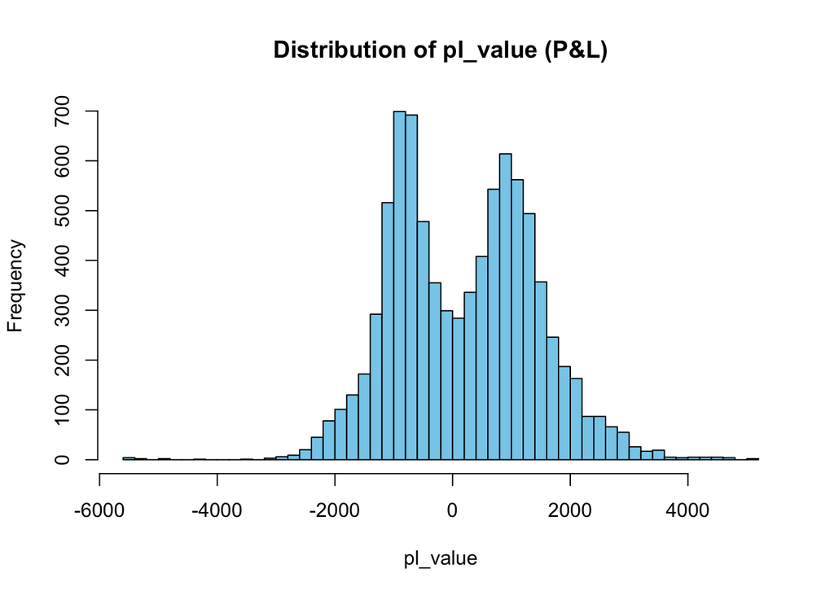

```r
hist(train$pl_value, breaks = 50, col = "skyblue", main = "Distribution of pl_value (P&L)", xlab = "pl_value")
```

## Assess correlation

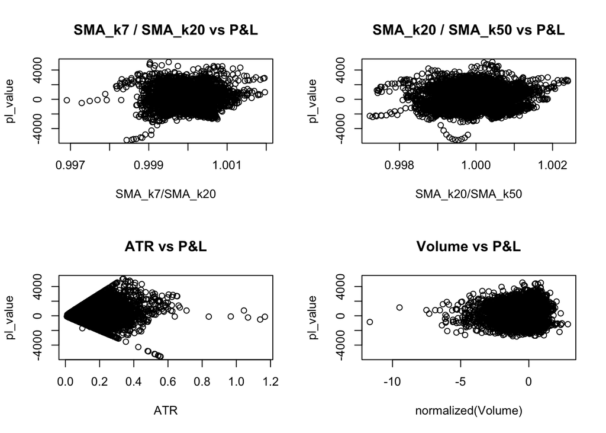

```r
par(mfrow=c(2,2))
plot(train$SMA_k7/train$SMA_k20, train$pl_value, main="SMA_k7 / SMA_k20 vs P&L", xlab="SMA_k7/SMA_k20", ylab="pl_value")
plot(train$SMA_k20/train$SMA_k50, train$pl_value, main="SMA_k20 / SMA_k50 vs P&L", xlab="SMA_k20/SMA_k50", ylab="pl_value")
plot(train$ATR, train$pl_value, main="ATR vs P&L", xlab="ATR", ylab="pl_value")
plot(log(train$norm_volume), train$pl_value, main="Volume vs P&L", xlab="normalized(Volume)", ylab="pl_value")
```

```r
par(mfrow=c(1,1))
```

ATR shows to have a weak correlation. I think the interaction of predictors with each other will be more important. Let’s see the interaction of volume and ATR

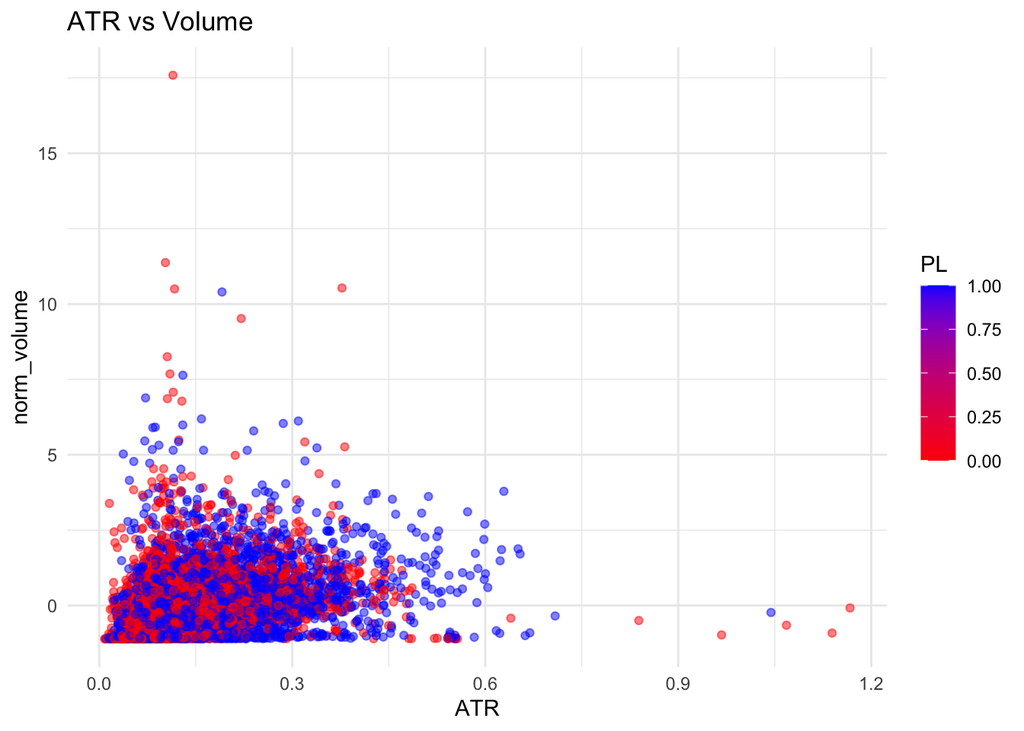

```r
library(ggplot2)
ggplot(train, aes(x=ATR, y=norm_volume, color=PL)) +
  geom_point(alpha=0.5) +
  scale_color_gradient2(mid="red", high="blue") +
  theme_minimal() +
  ggtitle("ATR vs Volume")
```

This shows us that low ATR and volume have a lower chance of being profitable. Though it tends to fluctuate quite a lot.

## Visualize predictor correlation matrix

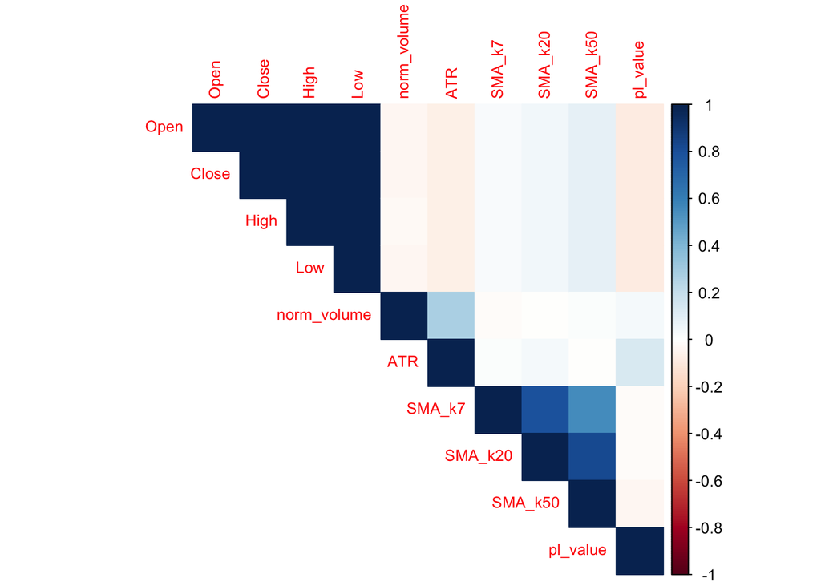

```r
library(corrplot)
numeric_vars <- train[, c("Open", "Close", "High", "Low", "norm_volume", "ATR", "SMA_k7", "SMA_k20", "SMA_k50", "pl_value")]
cor_matrix <- cor(numeric_vars, use="complete.obs")

corrplot(cor_matrix, method = "color", type = "upper", tl.cex = 0.8)
```

We will have to take steps to ensure we address multicollinearity, one way of doing this is looking at the VIF (Variance Inflation Factor). VIF is a diagnostic tool used to detect multicollinearity, which occurs when independent variables in a regression model are highly correlated with each other. High VIF values indicate that a variable’s variance is inflated due to multicollinearity. Values over 5 may have potential issues in fitting models.

```r
library(car)
vif_model <- lm(pl_value ~ ATR + SMA_k7 + SMA_k20+ SMA_k50+ norm_volume, data=train)
vif(vif_model)
```

```
##         ATR      SMA_k7     SMA_k20     SMA_k50 norm_volume
##    1.090462    2.979998    6.568685    3.491630    1.084155
```

This shows us that in order to reduce multicollinearity, we must omit `SMA_k20`

## Log regression

### Model Diagnostics and Theoretical Foundations

Logistic regression models the log-odds of a binary outcome as a linear function of predictors:

$$\log\left(\frac{p}{1-p}\right) = \beta_0
+ \beta_1X_1 + \beta_2X_2 + ... + \beta_kX_k$$

Where $p$ is the probability of a profitable trade. The coefficients represent the change in log-odds associated with a one-unit increase in the predictor, holding all other variables constant. We use all parameters and all interactions initially

```r
glm1 = glm(
  data = train,
  PL ~ (ATR + SMA_k7 + SMA_k50 + norm_volume)^4,
  family = "binomial"
)
```

### Assess

The full model will likely have only a handful of terms with significant probabilities because of multi-colinearity

```r
summary(glm1)
```

```
##
## Call:
## glm(formula = PL ~ (ATR + SMA_k7 + SMA_k50 + norm_volume)^4,
##     family = "binomial", data = train)
##
## Coefficients:
##                                Estimate Std. Error z value Pr(>|z|)
## (Intercept)                     -232142      80143  -2.897  0.00377 **
## ATR                              836341     265656   3.148  0.00164 **
## SMA_k7                           231899      80136   2.894  0.00381 **
## SMA_k50                          232029      80108   2.896  0.00377 **
## norm_volume                        5356      41581   0.129  0.89751
## ATR:SMA_k7                      -834679     265599  -3.143  0.00167 **
## ATR:SMA_k50                     -835772     265384  -3.149  0.00164 **
## ATR:norm_volume                  169629     180771   0.938  0.34806
## SMA_k7:SMA_k50                  -231786      80101  -2.894  0.00381 **
## SMA_k7:norm_volume                -5168      41578  -0.124  0.90107
## SMA_k50:norm_volume               -5550      41602  -0.133  0.89386
## ATR:SMA_k7:SMA_k50               834113     265327   3.144  0.00167 **
## ATR:SMA_k7:norm_volume          -170670     180792  -0.944  0.34516
## ATR:SMA_k50:norm_volume         -168573     180721  -0.933  0.35093
## SMA_k7:SMA_k50:norm_volume         5363      41599   0.129  0.89742
## ATR:SMA_k7:SMA_k50:norm_volume   169613     180742   0.938  0.34802
## ---
## Signif. codes:  0 '***' 0.001 '**' 0.01 '*' 0.05 '.' 0.1 ' ' 1
##
## (Dispersion parameter for binomial family taken to be 1)
##
##     Null deviance: 11710  on 8485  degrees of freedom
## Residual deviance: 11440  on 8470  degrees of freedom
## AIC: 11472
##
## Number of Fisher Scoring iterations: 5
```

### Residuals analysis

Regular residual plots don’t make sense in glm. Dunn and Gordon (2018) introduce quantile residuals for discrete response variables. Their primary benefits are they do not show weird patterns (due to variable’s discreteness). They are available in R via statmod::qresid().

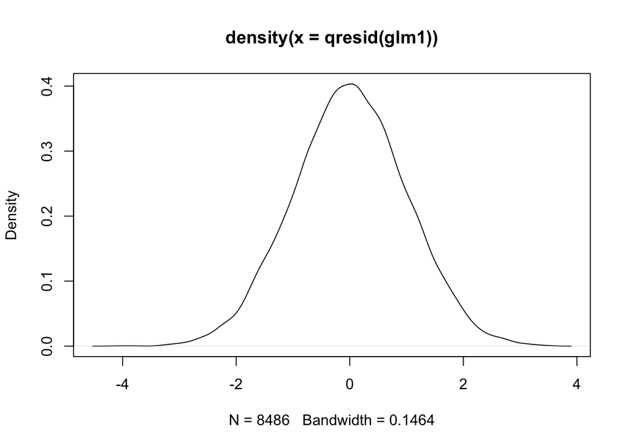

```r
library(statmod)
plot(density(qresid(glm1)))
```

This residuals do appear normally distributed. Which means there is no unexplained variance (non linearity or omitted variables) in the model.

### Variable Selection

The Akaike Information Criterion (AIC) balances model fit against complexity:

$$AIC = -2\ln(L) + 2k$$

```r
glm_step <- step(glm1, direction = "both", trace = 0)
summary(glm_step)
```

```
##
## Call:
## glm(formula = PL ~ ATR + SMA_k7 + SMA_k50 + norm_volume + ATR:SMA_k7 +
##     ATR:SMA_k50 + ATR:norm_volume + SMA_k7:SMA_k50 + SMA_k7:norm_volume +
##     SMA_k50:norm_volume + ATR:SMA_k7:SMA_k50 + ATR:SMA_k7:norm_volume +
##     ATR:SMA_k50:norm_volume + SMA_k7:SMA_k50:norm_volume, family = "binomial",
##     data = train)
##
## Coefficients:
##                              Estimate Std. Error z value Pr(>|z|)
## (Intercept)                -247907.02   79725.43  -3.110 0.001874 **
## ATR                         933383.19  262699.00   3.553 0.000381 ***
## SMA_k7                      247661.13   79718.34   3.107 0.001892 **
## SMA_k50                     247775.46   79695.83   3.109 0.001877 **
## norm_volume                  37115.84   24684.54   1.504 0.132683
## ATR:SMA_k7                 -931708.90  262634.99  -3.548 0.000389 ***
## ATR:SMA_k50                -932688.93  262491.86  -3.553 0.000381 ***
## ATR:norm_volume                 -9.95     425.47  -0.023 0.981343
## SMA_k7:SMA_k50             -247529.94   79688.68  -3.106 0.001895 **
## SMA_k7:norm_volume          -36930.50   24677.10  -1.497 0.134511
## SMA_k50:norm_volume         -37311.96   24716.20  -1.510 0.131142
## ATR:SMA_k7:SMA_k50          931018.40  262427.49   3.548 0.000389 ***
## ATR:SMA_k7:norm_volume       -1012.90     533.87  -1.897 0.057793 .
## ATR:SMA_k50:norm_volume       1022.36     219.22   4.664 3.11e-06 ***
## SMA_k7:SMA_k50:norm_volume   37126.66   24708.59   1.503 0.132947
## ---
## Signif. codes:  0 '***' 0.001 '**' 0.01 '*' 0.05 '.' 0.1 ' ' 1
##
## (Dispersion parameter for binomial family taken to be 1)
##
##     Null deviance: 11710  on 8485  degrees of freedom
## Residual deviance: 11441  on 8471  degrees of freedom
## AIC: 11471
##
## Number of Fisher Scoring iterations: 5
```

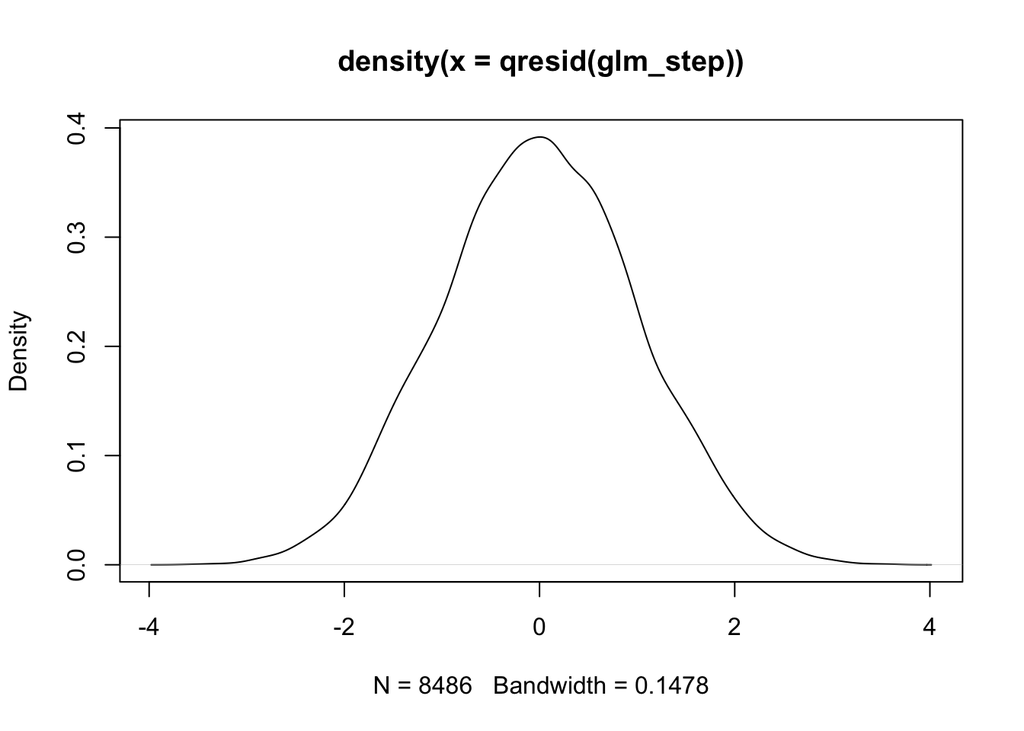

```r
plot(density(qresid(glm_step)))
```

This is still a lot of predictors, let’s try and do some subset selection. This method uses cross validation and fits models with the least mean squared error. By splitting the data up we are able to understand what is actually needed by minimizing MSE.

```r
library(glmnet)
# Get interaction matrix
X <- model.matrix(PL ~ (ATR + SMA_k7 + SMA_k50 + norm_volume)^4, data = train)[, -1]
y <- train$PL
cvfit <- cv.glmnet(X, y, family = "binomial", alpha = 1)

# coefs with least mse
lasso_coef <- coef(cvfit, s = "lambda.min")
selected_vars <- rownames(lasso_coef)[lasso_coef[,1] != 0][-1]  # exclude intercept
selected_vars
```

```
## [1] "ATR"                     "SMA_k50"
## [3] "ATR:norm_volume"         "ATR:SMA_k50:norm_volume"
```

These are a lot fewer than earlier, let’s fit this conservative model as well.

```r
glm_formula <- as.formula(paste("PL ~", paste(selected_vars, collapse = " + ")))
glm_cons <- glm(glm_formula, data = train, family = "binomial")
summary(glm_cons)
```

```
##
## Call:
## glm(formula = glm_formula, family = "binomial", data = train)
##
## Coefficients:
##                         Estimate Std. Error z value Pr(>|z|)
## (Intercept)               98.179     24.933   3.938 8.23e-05 ***
## ATR                        3.116      0.268  11.626  < 2e-16 ***
## SMA_k50                  -98.467     24.930  -3.950 7.82e-05 ***
## ATR:norm_volume          -99.534     64.220  -1.550    0.121
## ATR:SMA_k50:norm_volume   99.593     64.214   1.551    0.121
## ---
## Signif. codes:  0 '***' 0.001 '**' 0.01 '*' 0.05 '.' 0.1 ' ' 1
##
## (Dispersion parameter for binomial family taken to be 1)
##
##     Null deviance: 11710  on 8485  degrees of freedom
## Residual deviance: 11529  on 8481  degrees of freedom
## AIC: 11539
##
## Number of Fisher Scoring iterations: 4
```

### Assess performance

```r
pred_glm = ifelse(predict(glm_step,test,type="response")>0.5,1,0)
winrate = mean(pred_glm == test$PL)
print(winrate)
```

```
## [1] 0.5592082
```

```r
pred_glm_cons = ifelse(predict(glm_cons,test,type="response")>0.5,1,0)
winrate_cons = mean(pred_glm_cons == test$PL)
print(winrate_cons)
```

```
## [1] 0.5613291
```

```r
if (winrate_cons < winrate) {
  glm2 = glm_step
} else {
  glm2 = glm_cons
}
```

The accuracy is good, but it needs to be contextualized. The worst, bare bones model would trade on a coin flip. Let’s simulate $nrow(test)$ coin flips and compare it to a 55% win rate.

Simulate 1000 trading simulations with random buy indicators and see if winrate if better than it. `p = 0.05`. This is to weed out strategies that don’t perform better than random chance.

```r
n <- nrow(test)

# Simulate coin flips (baseline)
baseline_accuracy = c()
for (i in 1:1000) {
  set.seed(i)
  coin_flips <- rbinom(n, size = 1, prob = 0.5)
  baseline_accuracy <- c(mean(coin_flips == test$PL), baseline_accuracy)
}
set.seed(seed_num) # reproducibility
cat("Coin toss simulations that performed better than strategy :",length(baseline_accuracy[baseline_accuracy>winrate]) / length(baseline_accuracy))
```

```
## Coin toss simulations that performed better than strategy : 0
```

```r
# Use normal approximation

cat("\nWinrate p value:",pnorm(winrate, mean(baseline_accuracy), sd(baseline_accuracy), lower.tail = F))
```

```
##
## Winrate p value: 1.001858e-10
```

This is definitely below the p value.

### Buy threshold

We need to determine when to buy based on the threshold. This improves the win rate at the cost of fewer trades. This will miss out on a lot of winning trades too (False negatives). But to succeed at trading we need to minimize false positives. Precision, or $\frac{TP}{FP+TP}$ is much more important. “For estimating a binomial proportion, at least 10 successes and 10 failures is recommended for normal approximation intervals.” Reference: Agresti, A. (2013). Categorical Data Analysis (3rd ed.)

```r
# Define thresholds
probs <- 10^seq(-2, -10, length.out = 9)

fit_mean <- mean(glm2$fitted.values)
fit_sd <- sd(glm2$fitted.values)

prob_with_best_winrate = 0.05 # init
best_winrate = 0
for (prob in probs) {
  threshold <- qnorm(1 - prob, mean = fit_mean, sd = fit_sd)
  pred_glm <- ifelse(predict(glm_cons, train, type = "response") > threshold, 1, 0)

  true_positive <- sum(pred_glm == 1 & train$PL == 1)
  false_positive <- sum(pred_glm == 1 & train$PL == 0)
  total_predicted_positive <- sum(pred_glm == 1)
  if ((true_positive + false_positive) < 30) {
    break # CLT
  }
  winrate <- if (total_predicted_positive > 0) {
    true_positive / total_predicted_positive
  } else {
    NA
  }
  if (winrate > best_winrate) {
    best_winrate = winrate
    prob_with_best_winrate = prob
  }

  cat(sprintf("Prob = %e | TP = %d | FP = %d | Winrate = %.3f\n",
              prob, true_positive, false_positive, winrate))
}
```

```
## Prob = 1.000000e-02 | TP = 209 | FP = 76 | Winrate = 0.733
## Prob = 1.000000e-03 | TP = 92 | FP = 13 | Winrate = 0.876
## Prob = 1.000000e-04 | TP = 37 | FP = 6 | Winrate = 0.860
```

```r
best_threshold_glm = qnorm(1 - prob_with_best_winrate, mean = fit_mean, sd = fit_sd)
cat("Best winrate", best_winrate*100)
```

```
## Best winrate 87.61905
```

```r
cat("\nProbability with highest precision", prob_with_best_winrate)
```

```
##
## Probability with highest precision 0.001
```

```r
cat("\nThreshold", best_threshold_glm)
```

```
##
## Threshold 0.7614681
```

### Drawdown

`pl_value` is calculated with 1000 shares of SPY. In trading, using 2% of your portfolio in a trade is recommended, hence, The initial capital is set at $\frac{1}{0.02} * (1000 * Price)$.

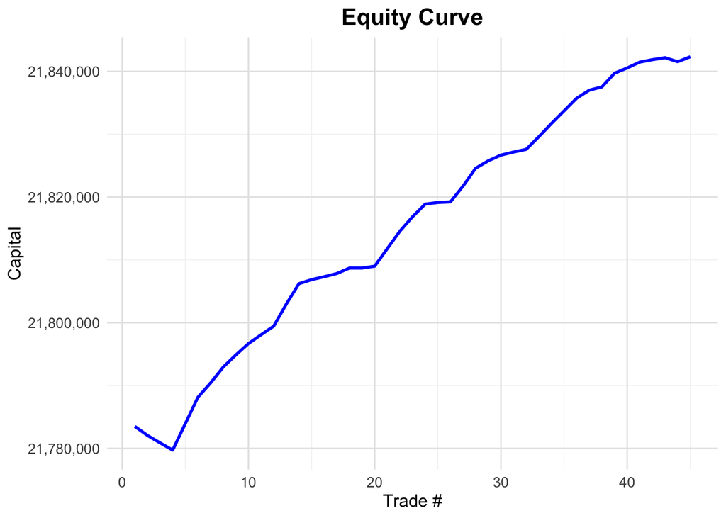

```r
initial_capital = (1/(0.02))*(1000 * sample(train$Open, 1)) # random price
capital <- initial_capital
drawdown <- c(capital)
wins <- c()

for (i in 1:nrow(test)) {
  pred_X <- predict(glm2, test[i, ], type = "response")
  if (pred_X > best_threshold_glm) {
    capital <- capital + test$pl_value[i]
    drawdown <- c(drawdown, capital)
    wins <- c(wins, test$pl_value[i])
  }
}

ggplot(data = data.frame(trade = 1:length(drawdown),
                        equity = drawdown),
       aes(x = trade, y = equity)) +
  geom_line(color = "blue", size = 1) +
  theme_minimal() +
  labs(title = "Equity Curve",
       x = "Trade #",
       y = "Capital") +
  theme(
    plot.title = element_text(size = 16, face = "bold", hjust = 0.5),
    axis.title = element_text(size = 12),
    axis.text = element_text(size = 10),
    panel.grid.major = element_line(color = "grey90"),
    panel.grid.minor = element_line(color = "grey95")
  ) +
  scale_y_continuous(labels = scales::comma)
```

```r
# Sharpe ratio (simplified version: mean return over SD of returns)
sharpe <- (tail(drawdown, 1) - initial_capital) / sd(wins)


peak = max(drawdown)
trough = min(drawdown)
max_drawdown = (trough-peak)/peak


cat("Initial Capital", initial_capital)
```

```
## Initial Capital 21783500
```

```r
cat("\nFinal Capital:", tail(drawdown, 1), "\n")
```

```
##
## Final Capital: 21842322
```

```r
cat("Sharpe Ratio:", round(sharpe, 3), "\n")
```

```
## Sharpe Ratio: 44.081
```

```r
cat("Max Drawdown:", max_drawdown*100, "%\n")
```

```
## Max Drawdown: -0.2865616 %
```

```r
cat("Returns:", ((capital/initial_capital)-1)*100, "%\n")
```

```
## Returns: 0.2700287 %
```

## XGboost

In this section, we use **XGBoost**, a gradient-boosted decision tree ensemble, to classify trade direction. Our goal is not just accuracy but **precision**, the ratio of true positives to all predicted positives. This focus reduces false positives—critical for real-world trading where bad trades are costly.

### Load Data

```r
library(xgboost)
library(Matrix)
library(caret)
data = train
X = model.matrix(PL ~ (ATR + SMA_k7 + SMA_k50 + norm_volume)^4, data=data)[, -1]
y = data$PL
dtrain = xgb.DMatrix(data = X, label = y)
```

### XGBoost Theoretical Framework

XGBoost builds an ensemble of decision trees sequentially, with each new tree correcting errors made by previous trees. The algorithm optimizes:

$$\mathcal{L}(\phi) = \sum_{i=1}^n l(y_i,
\hat{y}_i) + \sum_{k=1}^K \Omega(f_k)$$

Where: - $l$ is a differentiable convex loss function - $\hat{y}_i$ is the prediction - $\Omega$ is a regularization term controlling model complexity - $f_k$ represents the $k$-th tree in the ensemble

This approach allows XGBoost to capture complex non-linear relationships and interactions that linear models might miss.

### Cross-Validation and Training

We optimize for **AUC-PR** (area under the precision-recall curve), which directly measures precision vs. recall trade-offs.

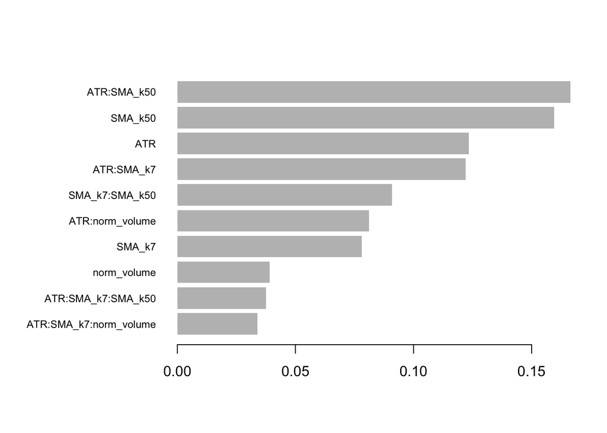

```r
param_grid <- expand.grid(
  eta = 0.05,
  max_depth = 3,
  subsample = 0.8,
  colsample_bytree = 0.8,
  eval_metric = "aucpr",         # maximize precision-recall AUC
  objective = "binary:logistic"  # output probabilities
)

watchlist = list(train = dtrain)

model <- xgb.train(
  params = as.list(param_grid),
  data = dtrain,
  nrounds = 100,
  watchlist = watchlist,
  verbose = 0
)

importance_matrix <- xgb.importance(model = model)
xgb.plot.importance(importance_matrix[1:10,])
```

### Threshold Selection Based on Precision

Rather than defaulting to a 0.5 decision threshold, we **optimize threshold** $T$ to maximize:

$$\text{Precision} = \frac{TP}{TP + FP}$$

We assume model predictions $\hat{y} \sim N(\mu, \sigma^2)$ and scan high quantiles (e.g., 0.99999) to reduce false positives.

```r
pred_probs <- predict(model, dtrain)
probs <- 10^seq(-2, -10, length.out = 9)

fit_mean = mean(pred_probs)
fit_sd = sd(pred_probs)

best_precision = 0
best_threshold_xg = 0.5

for (prob in probs){
  threshold <- qnorm(1 - prob, mean = fit_mean, sd = fit_sd)
  preds = ifelse(pred_probs > threshold, 1, 0)
  TP = sum(preds == 1 & train$PL == 1)
  FP = sum(preds == 1 & train$PL == 0)
  if ((TP + FP) < 30) {
    break # CLT
  }
  precision = ifelse((TP + FP) == 0, NA, TP / (TP + FP))
  if (!is.na(precision) && precision > best_precision){
    best_precision = precision
    best_threshold_xg = threshold
  }
  cat(sprintf("Prob = %e | TP = %d | FP = %d | Winrate = %.3f\n",
              prob, TP, FP, precision))
}
```

```
## Prob = 1.000000e-02 | TP = 190 | FP = 3 | Winrate = 0.984
## Prob = 1.000000e-03 | TP = 112 | FP = 0 | Winrate = 1.000
## Prob = 1.000000e-04 | TP = 58 | FP = 0 | Winrate = 1.000
```

```r
cat("Best Precision:", round(best_precision * 100, 2), "% at Threshold", best_threshold_xg, "\n")
```

```
## Best Precision: 100 % at Threshold 0.8364053
```

### Backtesting Equity Curve

Using the **test set**, we execute trades where the predicted probability $\hat{y} > T$, and track capital changes.

Let: - $C_0$: Initial capital - $r_i$: Profit/loss from trade $i$ - $T$: Threshold for high-precision entry

Then:
$$C_{i+1} = C_i + r_i \quad \text{only if } \hat{y}_i > T$$

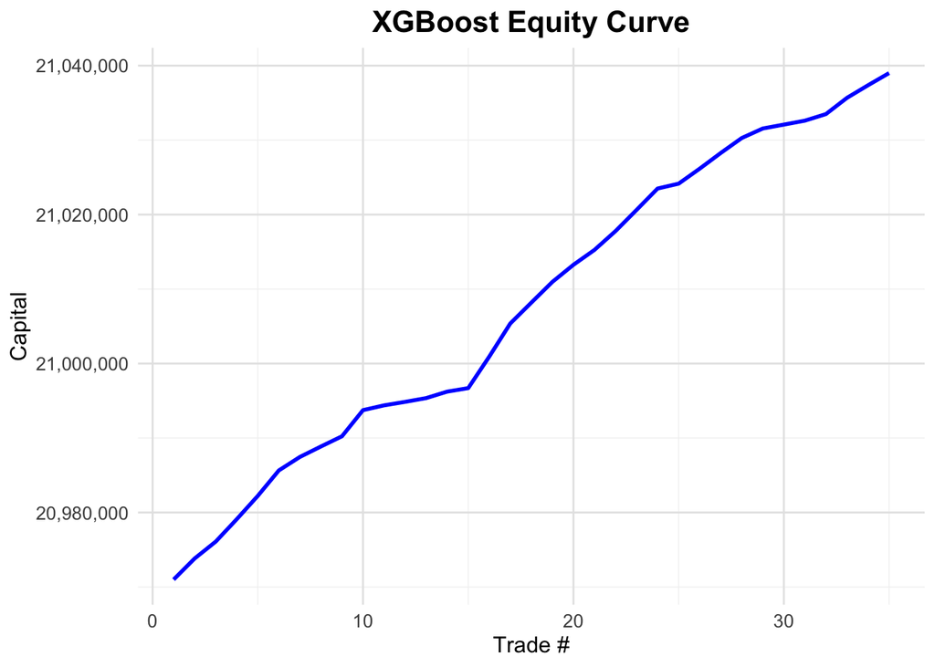

```r
test_X = model.matrix(PL ~ (ATR + SMA_k7 + SMA_k50 + norm_volume)^4, data=test)[, -1]
dtest = xgb.DMatrix(data = test_X)

pred_probs_xg <- predict(model, dtest)

initial_capital = (1/(0.02)) * (1000 * sample(train$Open, 1))
capital = initial_capital
drawdown = c(capital)
wins = c()

for (i in 1:nrow(test)) {
  pred_X = pred_probs_xg[i]
  if (pred_X > best_threshold_xg) {
    capital = capital + test$pl_value[i]
    drawdown = c(drawdown, capital)
    wins = c(wins, test$pl_value[i])
  }
}

ggplot(data = data.frame(trade = 1:length(drawdown),
                        equity = drawdown),
       aes(x = trade, y = equity)) +
  geom_line(color = "blue", size = 1) +
  theme_minimal() +
  labs(title = "XGBoost Equity Curve",
       x = "Trade #",
       y = "Capital") +
  theme(
    plot.title = element_text(size = 16, face = "bold", hjust = 0.5),
    axis.title = element_text(size = 12),
    axis.text = element_text(size = 10),
    panel.grid.major = element_line(color = "grey90"),
    panel.grid.minor = element_line(color = "grey95")
  ) +
  scale_y_continuous(labels = scales::comma)
```

```r
# Performance metrics
sharpe = (tail(drawdown, 1) - drawdown[1]) / sd(wins)
max_dd = min(drawdown - cummax(drawdown)) / max(drawdown)

cat("Final Capital:", capital, "\n")
```

```
## Final Capital: 21038997
```

```r
cat("Sharpe Ratio:", round(sharpe, 3), "\n")
```

```
## Sharpe Ratio: 61.431
```

```r
cat("Max Drawdown:", round(max_dd * 100, 2), "%\n")
```

```
## Max Drawdown: 0 %
```

### Commentary

XGBoost is particularly effective when: - Feature interactions matter - There are non-linear decision boundaries - **precision over recall**

Its ability to output probabilities makes it well-suited for **threshold tuning**, which we exploit using quantiles of the fitted distribution. By focusing on **extremely confident predictions**, we reduce bad trades and focus capital on high-reward setups.

## Support Vector Machines

Support Vector Machines (SVM) offer a powerful alternative approach for classification tasks in trading. Unlike linear models, SVMs can efficiently handle non-linear decision boundaries by projecting data into higher-dimensional spaces where separation becomes possible.

### Theoretical Foundation

The SVM algorithm finds the optimal hyperplane that maximizes the margin between classes. For linearly separable data, this involves solving:

$$\min_{\mathbf{w}, b} \frac{1}{2}
||\mathbf{w}||^2$$
$$\text{subject to
} y_i(\mathbf{w} \cdot \mathbf{x}_i + b) \geq 1 \text{ for all }
i$$

For non-linear boundaries, SVMs employ the “kernel trick” to implicitly map data to higher dimensions without explicitly computing the transformation. The decision function becomes:

$$f(\mathbf{x}) =
\text{sign}\left(\sum_{i=1}^n \alpha_i y_i K(\mathbf{x}_i, \mathbf{x}) +
b\right)$$

Where $K(\mathbf{x}_i, \mathbf{x})$ is the kernel function measuring similarity between points.

### Model Implementation

RBF (Radial Basis Function) kernel in your SVM is a solid choice for optimizing precision

```r
library(e1071)

X = model.matrix(PL ~ (ATR + SMA_k7 + SMA_k50 + norm_volume)^4, data=train)[, -1]
y = as.factor(train$PL)

svm_model <- svm(x = X, y = y,
                 kernel = "radial", # RBF is renowned for precision
                 probability = TRUE,
                 cost = 10,
                 gamma = 0.1)

summary(svm_model)
```

```
##
## Call:
## svm.default(x = X, y = y, kernel = "radial", gamma = 0.1, cost = 10,
##     probability = TRUE)
##
##
## Parameters:
##    SVM-Type:  C-classification
##  SVM-Kernel:  radial
##        cost:  10
##
## Number of Support Vectors:  7380
##
##  ( 3645 3735 )
##
##
## Number of Classes:  2
##
## Levels:
##  0 1
```

### Kernel Selection Rationale

The radial basis function (RBF) kernel is chosen for its ability to model complex non-linear decision boundaries. The RBF kernel computes:

$$K(\mathbf{x}_i, \mathbf{x}_j) =
\exp(-\gamma ||\mathbf{x}_i - \mathbf{x}_j||^2)$$

Where $\gamma$ controls the influence radius of each support vector. This allows the model to capture local patterns in the feature space that might be missed by linear models.

### Hyperparameter Tuning

Far too computationally expensive to run, `tune.svm` will take forever to compile. This is an area of improvement.

### Threshold Optimization for Precision

```r
svm_probs <- attr(predict(svm_model, X, probability = TRUE), "probabilities")[, "1"]

# Define threshold range
probs <- 10^seq(-2, -10, length.out = 9)
fit_mean <- mean(svm_probs)
fit_sd <- sd(svm_probs)

best_precision <- 0
best_threshold_svm <- 0.5

for (prob in probs) {
  threshold <- qnorm(1 - prob, mean = fit_mean, sd = fit_sd)
  preds <- ifelse(svm_probs > threshold, 1, 0)

  TP <- sum(preds == 1 & train$PL == 1)
  FP <- sum(preds == 1 & train$PL == 0)

  if ((TP + FP) < 30) {
    break # Ensure statistical significance
  }

  precision <- ifelse((TP + FP) == 0, NA, TP / (TP + FP))

  if (!is.na(precision) && precision > best_precision) {
    best_precision <- precision
    best_threshold_svm <- threshold
  }
  cat(sprintf("Prob = %e | TP = %d | FP = %d | Winrate = %.3f\n",
              prob, TP, FP, precision))
}
```

```
## Prob = 1.000000e-02 | TP = 36 | FP = 0 | Winrate = 1.000
```

```r
cat("SVM Best Precision:", round(best_precision * 100, 2), "% at Threshold", best_threshold_svm, "\n")
```

```
## SVM Best Precision: 100 % at Threshold 0.7322993
```

### Backtesting SVM Strategy

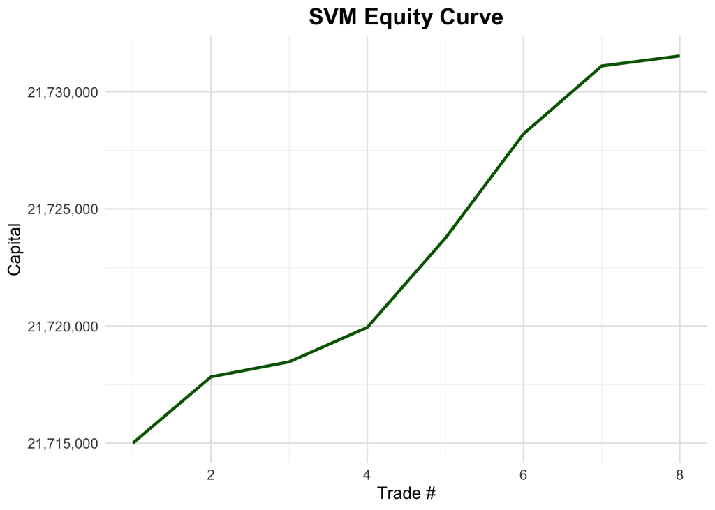

```r
#test data
test_X <- model.matrix(PL ~ (ATR + SMA_k7 + SMA_k50 + norm_volume)^4, data=test)[, -1]

# Get probability predictions for test set
test_probs_svm <- attr(predict(svm_model, test_X, probability = TRUE), "probabilities")[, "1"]

initial_capital <- (1/(0.02)) * (1000 * sample(train$Open, 1))
capital <- initial_capital
drawdown <- c(capital)
wins <- c()

for (i in 1:nrow(test)) {
  pred_X <- test_probs_svm[i]
  if (pred_X > best_threshold_svm) {
    capital <- capital + test$pl_value[i]
    drawdown <- c(drawdown, capital)
    wins <- c(wins, test$pl_value[i])
  }
}

ggplot(data = data.frame(trade = 1:length(drawdown),
                        equity = drawdown),
       aes(x = trade, y = equity)) +
  geom_line(color = "darkgreen", size = 1) +
  theme_minimal() +
  labs(title = "SVM Equity Curve",
       x = "Trade #",
       y = "Capital") +
  theme(
    plot.title = element_text(size = 16, face = "bold", hjust = 0.5),
    axis.title = element_text(size = 12),
    axis.text = element_text(size = 10),
    panel.grid.major = element_line(color = "grey90"),
    panel.grid.minor = element_line(color = "grey95")
  ) +
  scale_y_continuous(labels = scales::comma)
```

```r
# Calculate performance metrics
sharpe <- (tail(drawdown, 1) - drawdown[1]) / sd(wins)
max_dd <- min(drawdown - cummax(drawdown)) / max(drawdown)

cat("Initial Capital:", initial_capital, "\n")
```

```
## Initial Capital: 21715000
```

```r
cat("Final Capital:", capital, "\n")
```

```
## Final Capital: 21731533
```

```r
cat("Sharpe Ratio:", round(sharpe, 3), "\n")
```

```
## Sharpe Ratio: 10.647
```

```r
cat("Max Drawdown:", round(max_dd * 100, 2), "%\n")
```

```
## Max Drawdown: 0 %
```

```r
cat("Returns:", round(((capital/initial_capital)-1)*100, 2), "%\n")
```

```
## Returns: 0.08 %
```

### SVM Advantages for Trading

SVMs offer several advantages for financial prediction:

1. **Robustness to Outliers**: The support vector focus makes SVMs less sensitive to outliers compared to regression models.
2. **Effective in High-Dimensional Spaces**: SVMs perform well with many features relative to sample size, ideal for complex market data.
3. **Flexibility**: Through kernel selection, SVMs can model various decision boundaries without explicit feature engineering.
4. **Theoretical Guarantees**: SVMs are founded on statistical learning theory, providing formal bounds on generalization error.

The non-linear mapping capability is particularly valuable for capturing market regimes where relationships between indicators and outcomes change dynamically.

# Random chance

It’s possible that the data is looking at a biased subset of information. It’s possible that the overall trend from when this data was collected was upward, and these models wouldn’t hold up in turbulent market. To disprove this, A random trader was utilized, trading on a coin toss

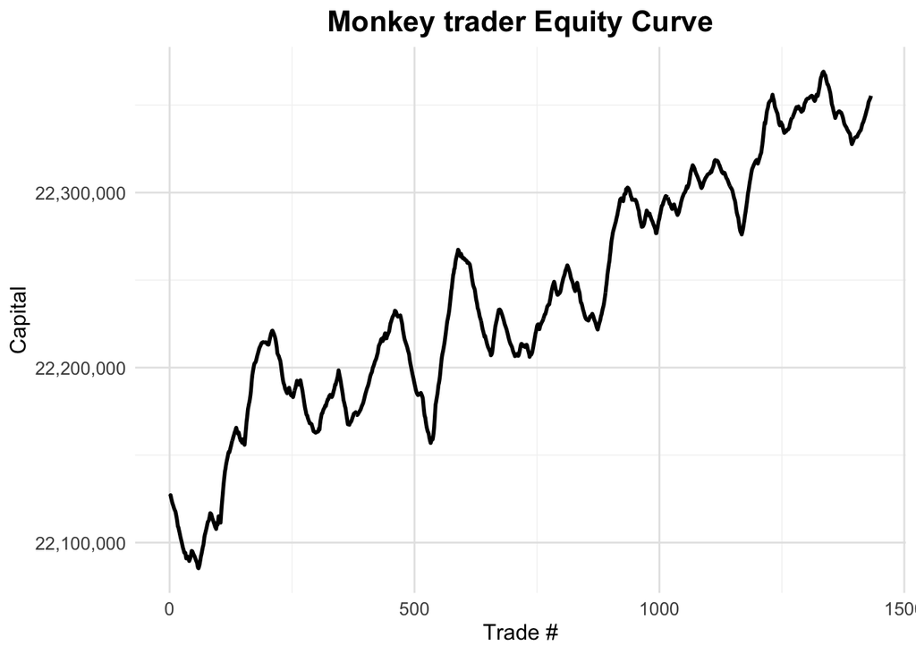

```r
initial_capital <- (1/(0.02)) * (1000 * sample(train$Open, 1))
capital <- initial_capital
drawdown <- c(capital)
wins <- c()

for (i in 1:nrow(test)) {
  if (round(runif(1,0,1)) == 1) {
    capital <- capital + test$pl_value[i]
    drawdown <- c(drawdown, capital)
    wins <- c(wins, test$pl_value[i])
  }
}

ggplot(data = data.frame(trade = 1:length(drawdown),
                        equity = drawdown),
       aes(x = trade, y = equity)) +
  geom_line(color = "black", size = 1) +
  theme_minimal() +
  labs(title = "Monkey trader Equity Curve",
       x = "Trade #",
       y = "Capital") +
  theme(
    plot.title = element_text(size = 16, face = "bold", hjust = 0.5),
    axis.title = element_text(size = 12),
    axis.text = element_text(size = 10),
    panel.grid.major = element_line(color = "grey90"),
    panel.grid.minor = element_line(color = "grey95")
  ) +
  scale_y_continuous(labels = scales::comma)
```

```r
# Calculate performance metrics
sharpe <- (tail(drawdown, 1) - drawdown[1]) / sd(wins)
max_dd <- min(drawdown - cummax(drawdown)) / max(drawdown)

cat("Initial Capital:", initial_capital, "\n")
```

```
## Initial Capital: 22126500
```

```r
cat("Final Capital:", capital, "\n")
```

```
## Final Capital: 22355314
```

```r
cat("Sharpe Ratio:", round(sharpe, 3), "\n")
```

```
## Sharpe Ratio: 189.418
```

```r
cat("Max Drawdown:", round(max_dd * 100, 2), "%\n")
```

```
## Max Drawdown: -0.34 %
```

```r
cat("Returns:", round(((capital/initial_capital)-1)*100, 2), "%\n")
```

```
## Returns: 1.03 %
```

# Ensemble prediction

For production trading systems, an ensemble approach combining these models might offer the most robust performance across varying market conditions. Each model captures different aspects of market behavior, and their combined signals could provide more reliable trading decisions than any single model alone.

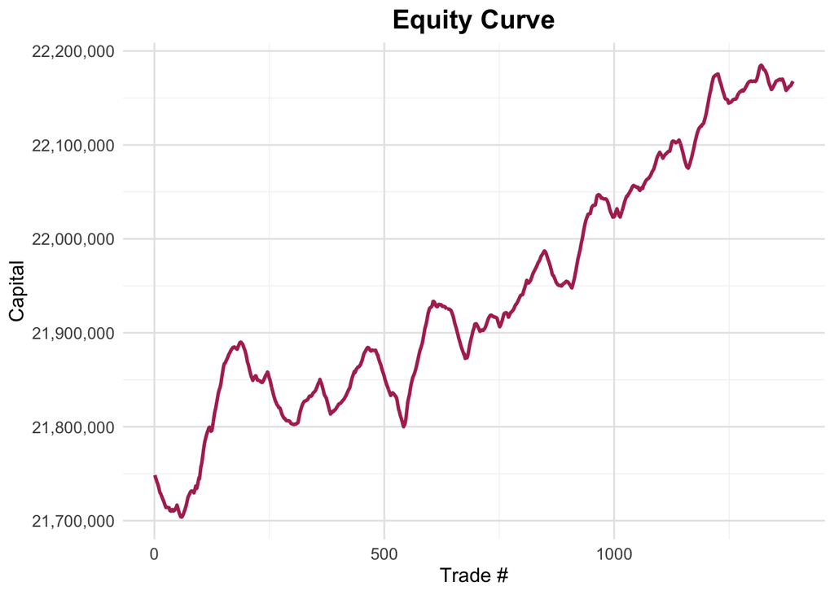

```r
initial_capital = (1/(0.02))*(1000 * sample(train$Open, 1)) # random price
capital <- initial_capital
drawdown <- c(capital)
wins <- c()

for (i in 1:nrow(test)) {
  pred_X <- predict(glm2, test[i, ], type = "response")
  pred_xg = pred_probs_xg[i]
  pred_svm = test_probs_svm[i]
  # Best threshold not used because all 3 never aligned in dataset
  if (pred_X > 0.5 & pred_xg > 0.5 & pred_svm > 0.5) {
    capital <- capital + test$pl_value[i]
    drawdown <- c(drawdown, capital)
    wins <- c(wins, test$pl_value[i])
  }
}

ggplot(data = data.frame(trade = 1:length(drawdown),
                        equity = drawdown),
       aes(x = trade, y = equity)) +
  geom_line(color = "maroon", size = 1) +
  theme_minimal() +
  labs(title = "Equity Curve",
       x = "Trade #",
       y = "Capital") +
  theme(
    plot.title = element_text(size = 16, face = "bold", hjust = 0.5),
    axis.title = element_text(size = 12),
    axis.text = element_text(size = 10),
    panel.grid.major = element_line(color = "grey90"),
    panel.grid.minor = element_line(color = "grey95")
  ) +
  scale_y_continuous(labels = scales::comma)
```

```r
# Sharpe ratio (simplified version: mean return over SD of returns)
sharpe <- (tail(drawdown, 1) - initial_capital) / sd(wins)


peak = max(drawdown)
trough = min(drawdown)
max_drawdown = (trough-peak)/peak


cat("Initial Capital", initial_capital)
```

```
## Initial Capital 21748500
```

```r
cat("\nFinal Capital:", tail(drawdown, 1), "\n")
```

```
##
## Final Capital: 22167811
```

```r
cat("Sharpe Ratio:", round(sharpe, 3), "\n")
```

```
## Sharpe Ratio: 306.215
```

```r
cat("Max Drawdown:", max_drawdown*100, "%\n")
```

```
## Max Drawdown: -2.16807 %
```

```r
cat("Returns:", ((capital/initial_capital)-1)*100, "%\n")
```

```
## Returns: 1.927999 %
```

[output not shown]